# In-class Exercise 7

In this exercise, I learnt how to create a graph network with R.

Sia Heng Guang https://www.linkedin.com/in/hengguang/ (MITB Analytics Track)https://scis.smu.edu.sg/  
2022-03-12

## Installing relevant libraries

```r
packages = c('igraph', 'tidygraph',
             'ggraph', 'visNetwork',
             'lubridate', 'clock',
             'tidyverse', 'circlize',
             'chorddiag')
for(p in packages){
  if(!require(p, character.only = T)){
    install.packages(p)
  }
  library(p, character.only = T)
}
```

## Analysing and Visaulising Network Data

### Importing and examining data

```r
GAStech_nodes <- read_csv("data/GAStech_email_node.csv")
GAStech_edges <- read_csv("data/GAStech_email_edge-v2.csv")
```

We can examine the structure of the data using glimpse() of dplyr.

```r
glimpse(GAStech_edges)
```

```
Rows: 9,063
Columns: 8
$ source      <dbl> 43, 43, 44, 44, 44, 44, 44, 44, 44, 44, 44, 44, ~
$ target      <dbl> 41, 40, 51, 52, 53, 45, 44, 46, 48, 49, 47, 54, ~
$ SentDate    <chr> "6/1/2014", "6/1/2014", "6/1/2014", "6/1/2014", ~
$ SentTime    <time> 08:39:00, 08:39:00, 08:58:00, 08:58:00, 08:58:0~
$ Subject     <chr> "GT-SeismicProcessorPro Bug Report", "GT-Seismic~
$ MainSubject <chr> "Work related", "Work related", "Work related", ~
$ sourceLabel <chr> "Sven.Flecha", "Sven.Flecha", "Kanon.Herrero", "~
$ targetLabel <chr> "Isak.Baza", "Lucas.Alcazar", "Felix.Resumir", "~
```

We can see that the SentDate is actually stored as chr (character) type instead of date data type. Hence, we need to change it back to date type.

```r
GAStech_edges$SentDate  = dmy(GAStech_edges$SentDate)
GAStech_edges$Weekday = wday(GAStech_edges$SentDate,
                             label = TRUE,
                             abbr = FALSE)
```

Take note of the following:

- both dmy() and wday() are functions of lubridate package. lubridate is an R package that makes it easier to work with dates and times.
- dmy() transforms the SentDate to Date data type.
- wday() returns the day of the week as a decimal number or an ordered factor if label is TRUE. The argument abbr is FALSE keep the daya spells in full, i.e. Monday. The function will create a new column in the data.frame i.e. Weekday and the output of wday() will save in this newly created field.
- the values in the Weekday field are in ordinal scale.

Lets check the data again.

```r
glimpse(GAStech_edges)
```

```
Rows: 9,063
Columns: 9
$ source      <dbl> 43, 43, 44, 44, 44, 44, 44, 44, 44, 44, 44, 44, ~
$ target      <dbl> 41, 40, 51, 52, 53, 45, 44, 46, 48, 49, 47, 54, ~
$ SentDate    <date> 2014-01-06, 2014-01-06, 2014-01-06, 2014-01-06,~
$ SentTime    <time> 08:39:00, 08:39:00, 08:58:00, 08:58:00, 08:58:0~
$ Subject     <chr> "GT-SeismicProcessorPro Bug Report", "GT-Seismic~
$ MainSubject <chr> "Work related", "Work related", "Work related", ~
$ sourceLabel <chr> "Sven.Flecha", "Sven.Flecha", "Kanon.Herrero", "~
$ targetLabel <chr> "Isak.Baza", "Lucas.Alcazar", "Felix.Resumir", "~
$ Weekday     <ord> Monday, Monday, Monday, Monday, Monday, Monday, ~
```

It seems like the date is now in the correct format.

### Wrangling Attributes

```r
GAStech_edges_aggregated <- GAStech_edges %>%
  filter(MainSubject == "Work related") %>%
  group_by(source, target, Weekday) %>%
    summarise(Weight = n()) %>%
  filter(source!=target) %>%
  filter(Weight > 1) %>%
  ungroup()
```

### Using tidygraph to prepare the graph chart

The code chunk below is first used to create a tbl_graph object, which will then be converted to a graph chart using ggraph.

```r
GAStech_graph <- tbl_graph(nodes = GAStech_nodes,
                           edges = GAStech_edges_aggregated,
                           directed = TRUE)
```

Reviewing the output graph object.

```r
GAStech_graph
```

```
# A tbl_graph: 54 nodes and 1456 edges
#
# A directed multigraph with 1 component
#
# Node Data: 54 x 4 (active)
     id label               Department     Title
  <dbl> <chr>               <chr>          <chr>
1     1 Mat.Bramar          Administration Assistant to CEO
2     2 Anda.Ribera         Administration Assistant to CFO
3     3 Rachel.Pantanal     Administration Assistant to CIO
4     4 Linda.Lagos         Administration Assistant to COO
5     5 Ruscella.Mies.Haber Administration Assistant to Engineering G~
6     6 Carla.Forluniau     Administration Assistant to IT Group Mana~
# ... with 48 more rows
#
# Edge Data: 1,456 x 4
   from    to Weekday   Weight
  <int> <int> <ord>      <int>
1     1     2 Monday         4
2     1     2 Tuesday        3
3     1     2 Wednesday      5
# ... with 1,453 more rows
```

If we want to rearrange the rows in the edges to list those with the highest ‘weight’ first, we can use activate() and then arrange().

```r
GAStech_graph %>%
  activate(edges) %>%
  arrange(desc(Weight))
```

```
# A tbl_graph: 54 nodes and 1456 edges
#
# A directed multigraph with 1 component
#
# Edge Data: 1,456 x 4 (active)
   from    to Weekday Weight
  <int> <int> <ord>    <int>
1    40    41 Tuesday     23
2    40    43 Tuesday     19
3    41    43 Tuesday     15
4    41    40 Tuesday     14
5    42    41 Tuesday     13
6    42    40 Tuesday     12
# ... with 1,450 more rows
#
# Node Data: 54 x 4
     id label           Department     Title
  <dbl> <chr>           <chr>          <chr>
1     1 Mat.Bramar      Administration Assistant to CEO
2     2 Anda.Ribera     Administration Assistant to CFO
3     3 Rachel.Pantanal Administration Assistant to CIO
# ... with 51 more rows
```

## Plotting Network Data with ggraph

To plot the network graph, we require three attributes - nodes, edges and layouts.

A basic network graph can be plotted using ggraph(), geom-edge_link() and geom_node_point(). ggraph() can use either an igraph object or a tbl_graph object, the latter which we created earlier.

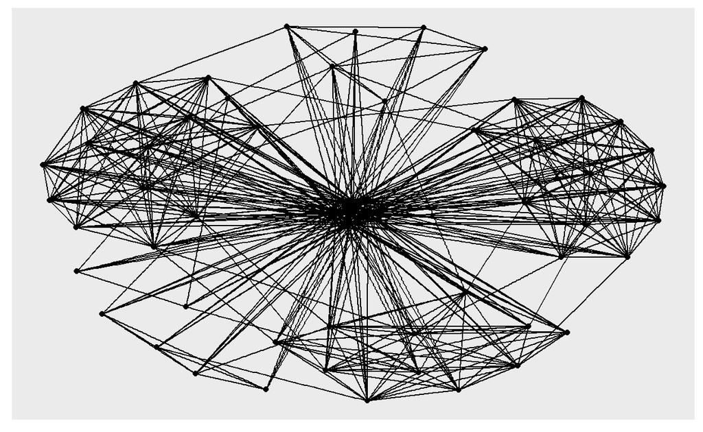

```r
ggraph(GAStech_graph) +
  geom_edge_link() +
  geom_node_point()
```

We can also customise a theme for the graph.

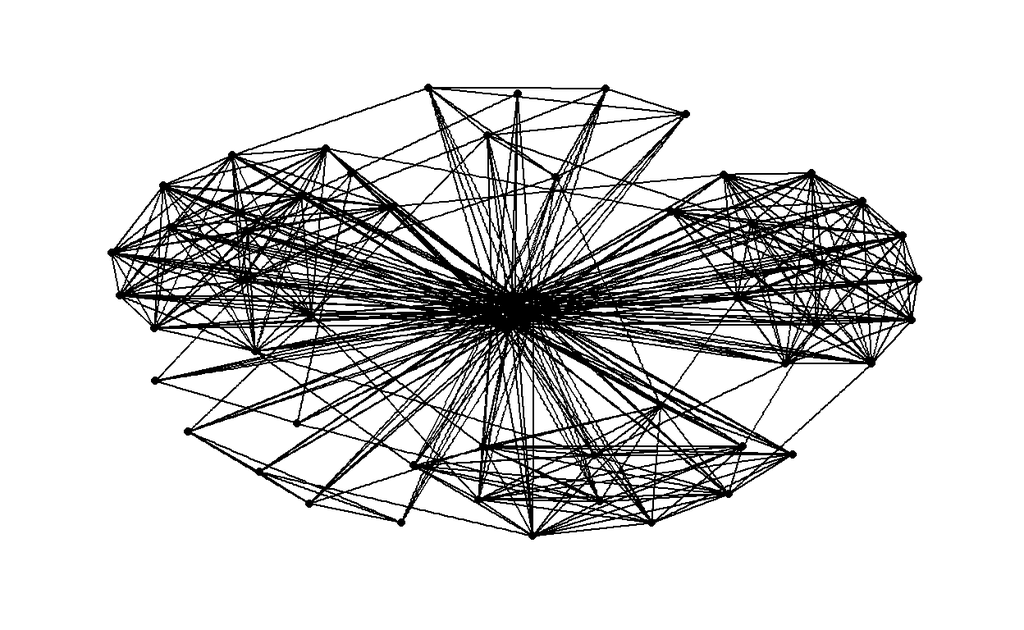

```r
g <- ggraph(GAStech_graph) +
  geom_edge_link(aes()) +
  geom_node_point(aes())
g + theme_graph()
```

theme_graph() makes it easy to change the colours of the plot.

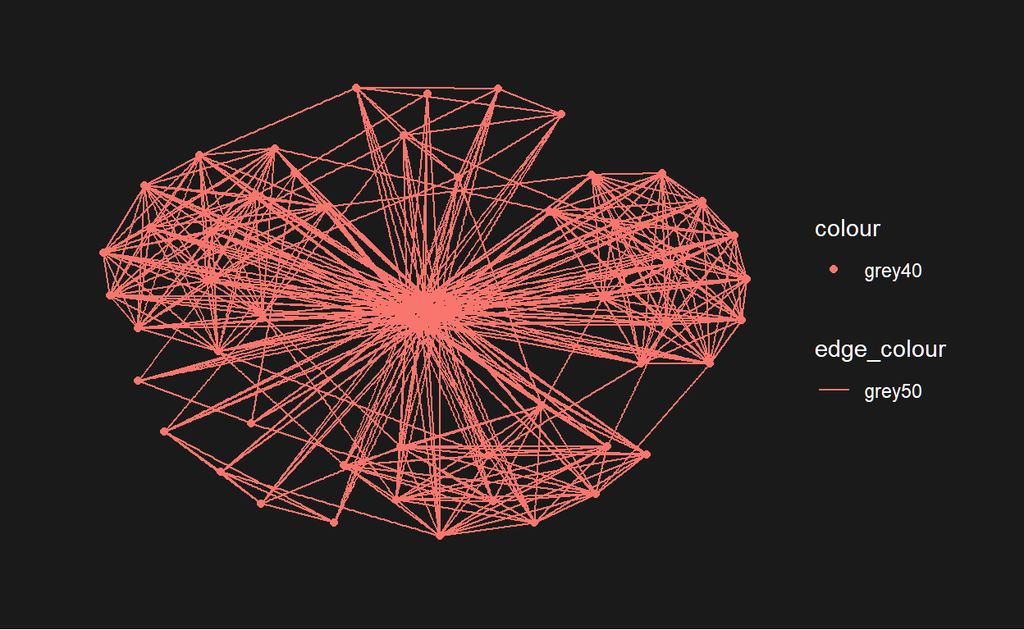

```r
g <- ggraph(GAStech_graph) +
  geom_edge_link(aes(colour = 'grey50')) +
  geom_node_point(aes(colour = 'grey40'))
g + theme_graph(background = 'grey10',
                text_colour = 'white')
```

We can use different layouts of the ggraph() function, such as the Fruchterman and Reingold layout.

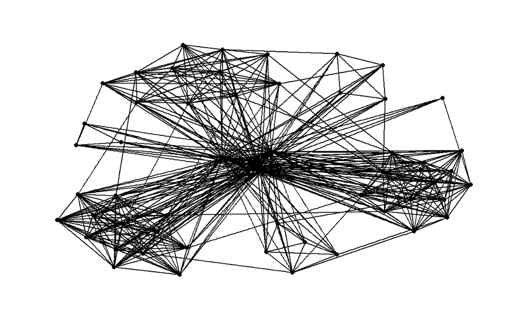

```r
g <- ggraph(GAStech_graph,
            layout = "fr") +
  geom_edge_link(aes()) +
  geom_node_point(aes())
g + theme_graph()
```

Because the geom_node_point has the same attributes as geo_point of ggplot2, we can customise how the different points look like by passing through the colour and size arguments.

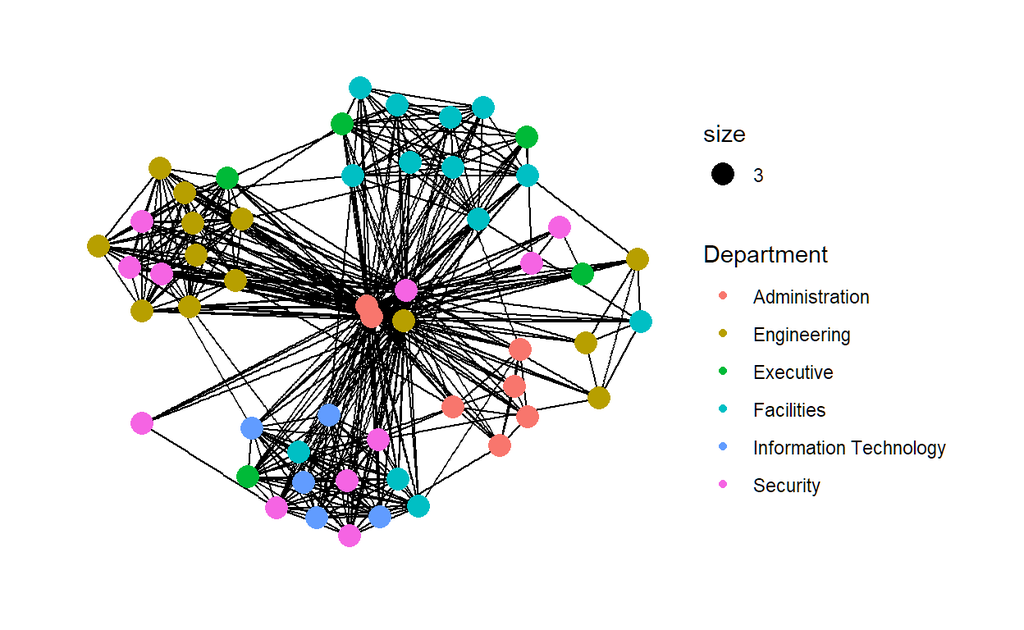

```r
g <- ggraph(GAStech_graph,
            layout = "nicely") +
  geom_edge_link(aes()) +
  geom_node_point(aes(colour = Department,
                      size = 3))
g + theme_graph()
```

We can also vary the thickness of the edges depending on the weights of the network, by adding attributes to geom_edge_link.

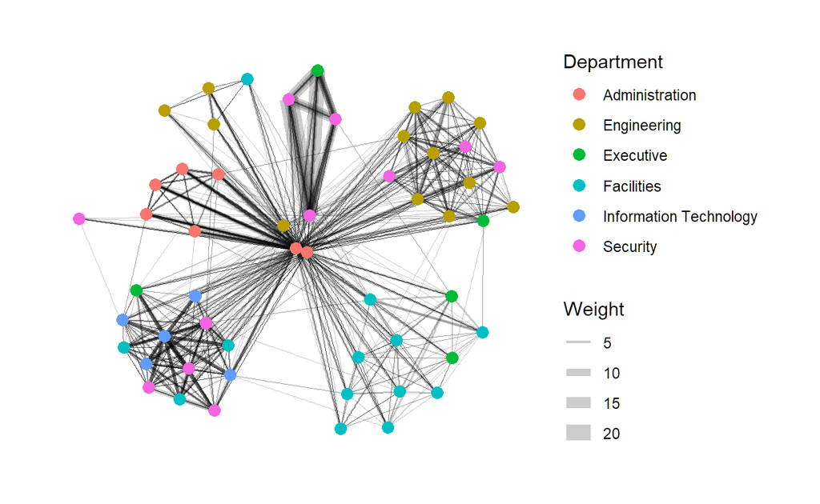

```r
g <- ggraph(GAStech_graph,
            layout = "nicely") +
  geom_edge_link(aes(width=Weight),
                 alpha=0.2) +
  scale_edge_width(range = c(0.1, 5)) +
  geom_node_point(aes(colour = Department),
                  size = 3)
g + theme_graph()
```

## Using facets to plot network graphs

We might want to separate the information by weekdays. For this, we will use the facet_edges() function to target the **edges.** The theme() attribute is also used to change the legend position to the bottom.

For the facet_edges() function, we pass through the th_foreground change the foreground colour and add a border to segregate the plots.

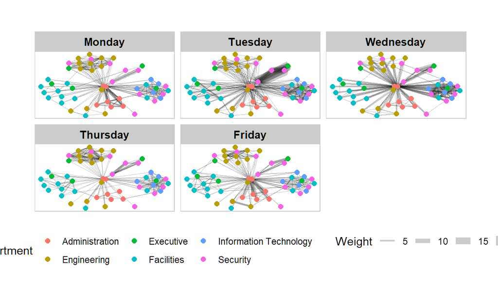

```r
set_graph_style()
g <- ggraph(GAStech_graph,
            layout = "nicely") +
  geom_edge_link(aes(width=Weight),
                 alpha=0.2) +
  scale_edge_width(range = c(0.1, 5)) +
  geom_node_point(aes(colour = Department),
                  size = 2) +
  theme(legend.position = 'bottom')

g + facet_edges(~Weekday) +
  th_foreground(foreground = "grey80",
                border = TRUE)
```

We can also use facet_nodes() to plot facets, by targeting the **nodal points.**

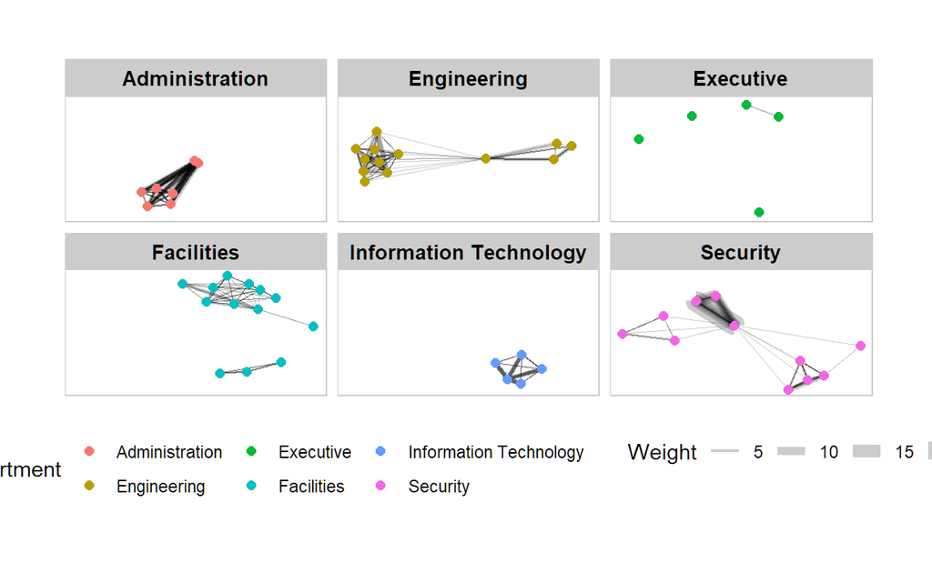

```r
set_graph_style()
g <- ggraph(GAStech_graph,
            layout = "nicely") +
  geom_edge_link(aes(width=Weight),
                 alpha=0.2) +
  scale_edge_width(range = c(0.1, 5)) +
  geom_node_point(aes(colour = Department),
                  size = 2)

g + facet_nodes(~Department)+
  th_foreground(foreground = "grey80",
                border = TRUE) +
  theme(legend.position = 'bottom')
```

### Centrality indices in a network

There are four well-known centrality measures, namely: degree, betweenness, closeness and eigenvector.

We can **mutate** the GAStech_graph data using the centrality_betweenness() of tidygraph to show the betweenness between the nodes.

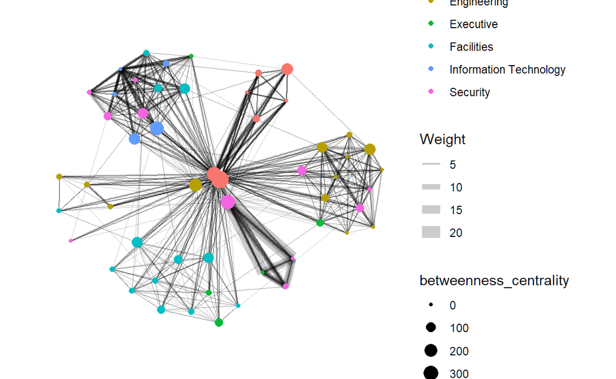

```r
g <- GAStech_graph %>%
  mutate(betweenness_centrality = centrality_betweenness()) %>%
  ggraph(layout = "fr") +
  geom_edge_link(aes(width=Weight),
                 alpha=0.2) +
  scale_edge_width(range = c(0.1, 5)) +
  geom_node_point(aes(colour = Department,
            size=betweenness_centrality))
g + theme_graph()
```

An easier method is to use ggraph *directly*, which added the centrality measures in the calls from ggraph v2.0 onwards.

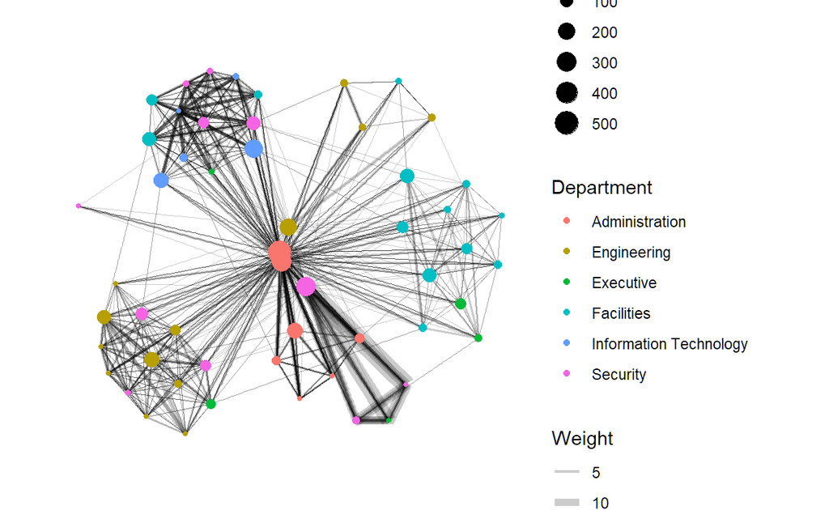

```r
g <- GAStech_graph %>%
  ggraph(layout = "fr") +
  geom_edge_link(aes(width=Weight),
                 alpha=0.2) +
  scale_edge_width(range = c(0.1, 5)) +
  geom_node_point(aes(colour = Department,
                      size = centrality_betweenness()))
g + theme_graph()
```

### Visualising Community

idygraph package inherits many of the community detection algorithms imbedded into igraph and makes them available to us, including Edge-betweenness (group_edge_betweenness), Leading eigenvector (group_leading_eigen), Fast-greedy (group_fast_greedy), Louvain (group_louvain), Walktrap (group_walktrap), Label propagation (group_label_prop), InfoMAP (group_infomap), Spinglass (group_spinglass), and Optimal (group_optimal). Some community algorithms are designed to take into account direction or weight, while others ignore it.

We use the group_edge_betweenness() function below.

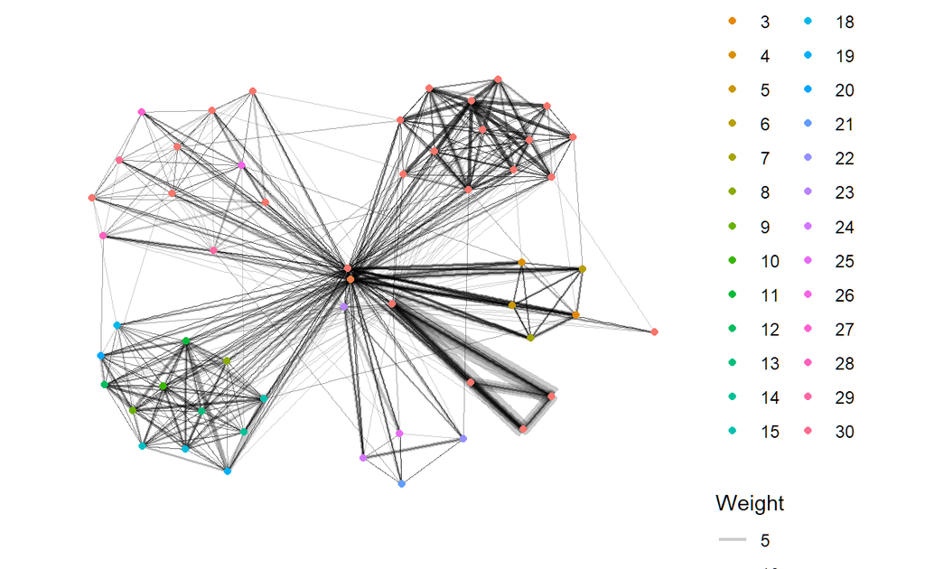

```r
g <- GAStech_graph %>%
  mutate(community = as.factor(group_edge_betweenness(weights = Weight, directed = TRUE))) %>%
  ggraph(layout = "fr") +
  geom_edge_link(aes(width=Weight),
                 alpha=0.2) +
  scale_edge_width(range = c(0.1, 5)) +
  geom_node_point(aes(colour = community))
g + theme_graph()
```

## Building Interactive Network Graph with visNetwork

- visNetwork() is a R package for network visualization, using vis.js javascript library.
- visNetwork() function uses a nodes list and edges list to create an interactive graph.
  - The nodes list must include an “id” column, and the edge list must have “from” and “to” columns.
  - The function also plots the labels for the nodes, using the names of the actors from the “label” column in the node list.
- The resulting graph is fun to play around with.
  - You can move the nodes and the graph will use an algorithm to keep the nodes properly spaced.
  - You can also zoom in and out on the plot and move it around to re-center it.

```r
GAStech_edges_aggregated <- GAStech_edges %>%
  left_join(GAStech_nodes, by = c("sourceLabel" = "label")) %>%
  rename(from = id) %>%
  left_join(GAStech_nodes, by = c("targetLabel" = "label")) %>%
  rename(to = id) %>%
  filter(MainSubject == "Work related") %>%
  group_by(from, to) %>%
    summarise(weight = n()) %>%
  filter(from!=to) %>%
  filter(weight > 1) %>%
  ungroup()
```

The visNetwork requires the data to be in the form of “from and to”.

We can then use the visNetwork() function to plot a simple interactive network graph.

```r
visNetwork(GAStech_nodes,
           GAStech_edges_aggregated)
```

[interactive chart not shown]

We can plot this into a layout to interact with it better. (Drag the points to see how it moves)

```r
visNetwork(GAStech_nodes,
           GAStech_edges_aggregated) %>%
  visIgraphLayout(layout = "layout_with_fr")
```

[interactive chart not shown]

### Working with Visual Attributes - Nodes

visNetwork() looks for a field called “group” in the nodes object and colour the nodes according to the values of the group field.

The code chunk below rename *Department* field to *group.*

```r
GAStech_nodes <- GAStech_nodes %>%
  rename(group = Department)
```

When we rerun the code below, the visNetwork shades each node by assigning a unique colour to each category.

```r
visNetwork(GAStech_nodes,
           GAStech_edges_aggregated) %>%
  visIgraphLayout(layout = "layout_with_fr") %>%
  visLegend() %>%
  visLayout(randomSeed = 123)
```

[interactive chart not shown]

### Working with Visual Attributes - Edges

In the code run below [visEdges()](http://datastorm-open.github.io/visNetwork/edges.html) is used to symbolise the edges.

- The argument arrows is used to define where to place the arrow.
- The smooth argument is used to plot the edges using a smooth curve.

```r
visNetwork(GAStech_nodes,
           GAStech_edges_aggregated) %>%
  visIgraphLayout(layout = "layout_with_fr") %>%
  visEdges(arrows = "to",
           smooth = list(enabled = TRUE,
                         type = "curvedCW")) %>%
  visLegend() %>%
  visLayout(randomSeed = 123)
```

[interactive chart not shown]

### Interactivity using visOptions()

In the code chunk below, [visOptions()](http://datastorm-open.github.io/visNetwork/options.html) is used to incorporate interactivity features in the data visualisation.

- The argument *highlightNearest* highlights nearest when clicking a node.
- The argument *nodesIdSelection* adds an id node selection creating an HTML select element.

```r
visNetwork(GAStech_nodes,
           GAStech_edges_aggregated) %>%
  visIgraphLayout(layout = "layout_with_fr") %>%
  visOptions(highlightNearest = TRUE,
             nodesIdSelection = TRUE) %>%
  visLegend() %>%
  visLayout(randomSeed = 123)
```

[interactive chart not shown]

## Visualising Flows between Entities: Chord Diagram method

Sometimes, we want to visualise flows or interaction between entities such as trade, by using a chord diagram.

Two R packages will be used, they are:

- circlize, in particular the chordDiagram().
- chorddiag package. Notice that this package is not in R cran. You need to install it by using the code chunk below.

```r
devtools::install_github("mattflor/chorddiag")
```

### Importing and examining data

In this exercise, we use [Migration and Remittances Data](https://www.worldbank.org/en/topic/migrationremittancesdiasporaissues/brief/migration-remittances-data) from The World Bank.

```r
mig_data <- read_csv(
  "data/bilateral_migration2017.csv")
```

### Data Wrangling

We use the pivot_longer() of dplyr to pivot them into a single column called Destination. A new column called Migrant will be used to store the migrant values.

```r
mig_data <- mig_data %>%
  pivot_longer(cols = c(2:215),
               names_to = "Destination",
               values_to = "Migrants",)
```

Next, the code chunk below will be used to convert the Origin and Destination data type from Character into Factor.

```r
mig_data$`Origin` <- as.factor(
  mig_data$Origin)
mig_data$`Destination` <- as.factor(
  mig_data$Destination)
```

We filter the countries to exclude flows that are less than 1m, to show significant flows.

```r
mig_data_selected <-mig_data %>%
  filter(Migrants >= 1000000)
```

### Preparing the data in an adjacency matrix

Both chordDiagram() and chorddiag() require the input data in an adjacency matrix format. The code chunk below will be used to convert the tibble data frame into an adjacency matrix.

```r
adj_matrix <- as.matrix(
  as_adjacency_matrix(
    as_tbl_graph(mig_data_selected),
    attr = "Migrants"))
```

## Plotting a basic Chord Diagram using circlize

The chordDiagram() function plots a basic chord diagram to visualise the data.

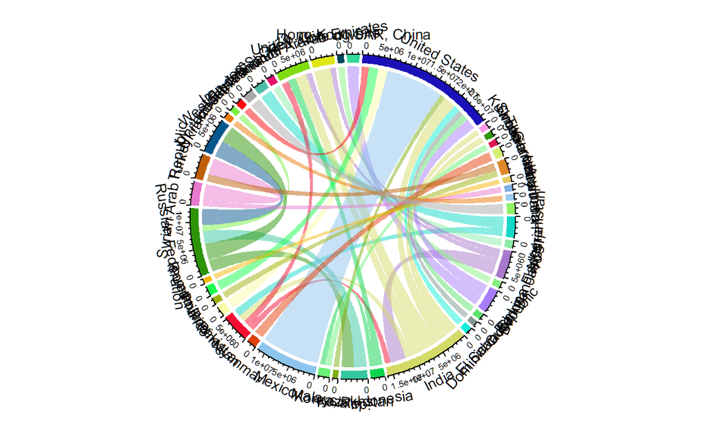

```r
chordDiagram(adj_matrix,
             transparency = 0.5)
```

## Plotting a interactive chord diagram

We can emphasize the large flows using the chorddiag() function with groups.

```r
chorddiag(data = adj_matrix,
                 height = 1000,
                 width = 1000,
                 groupnamePadding = 30,
                 groupPadding = 3,
                 groupColors = c("#ffffe5", "#fff7bc", "#fee391", "#fec44f", "#fe9929",
                                 "#ec7014", "#cc4c02", "#8c2d04"),
                 groupnameFontsize = 13 ,
                 showTicks = FALSE,
                 margin=150,
                 tooltipGroupConnector = "    &#x25B6;    ",
                 chordedgeColor = "#B3B6B7")
```

[interactive chart not shown]